# STA 5207: Homework 6

Due: Friday, March 1 by 11:59 PM

Include your R code in an R chunks as part of your answer. In addition, your written answer to each exercise should be self-contained so that the grader can determine your solution without reading your code or deciphering its output.

## Exercise 1 (Diagnostics for Teenage Gambling Data) [40 points]

For this exercise we will use the `teengamb` data set from the `faraway` package. You can also find that data in `teengamb.csv` on Canvas. You can use `?teengamb` to learn about the data set. The variables in the data set are

- `sex`: 0 = male, 1 = female.
- `status`: Socioeconomic status score based on parents’ occupation.
- `income`: in pounds per week.
- `verbal`: verbal score in words out of 12 correctly defined.
- `gamble`: expenditure on gambling in pounds per year.

In the following exercise, use `gamble` as the response and the other variables as predictors. Some of these questions are subjective, so there may not be a “right” answer. Just make sure to justify your answer based on the plots and statistical tests.

```r
library(faraway)
library(olsrr)
library(lmtest)
```

1. (8 points) Check the constant variance assumption for this model using a graphical method and a hypothesis test at the $\alpha = 0.05$ significance level. Do you feel it has been violated? Justify your answer. Include any plots in your response.

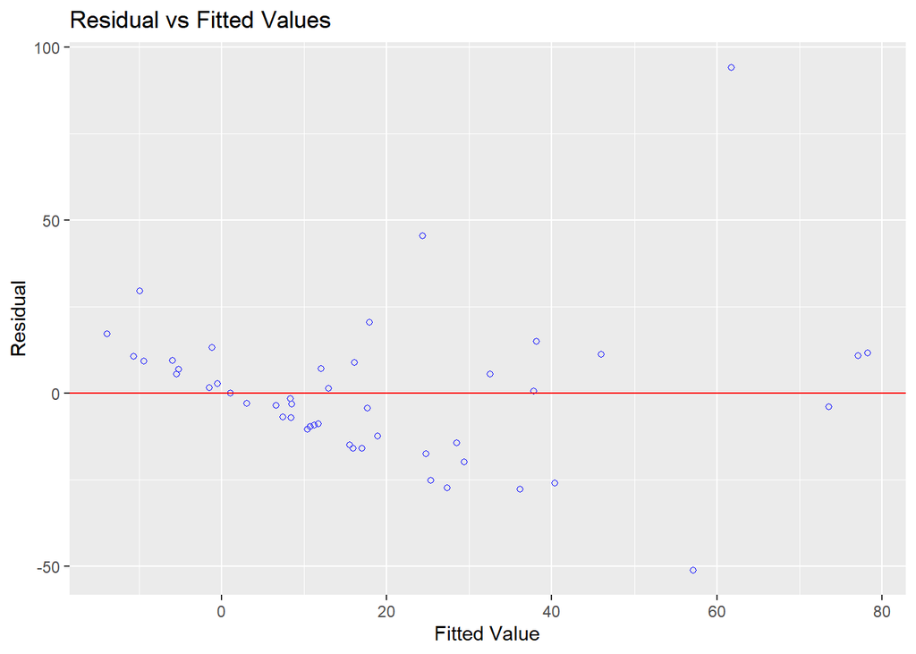

   ```r
   model = lm(gamble ~ ., data = teengamb)
   ols_plot_resid_fit(model)
   ```

   ```r
   bptest(model)
   ```

   ```
   ##
   ##  studentized Breusch-Pagan test
   ##
   ## data:  model
   ## BP = 6.4288, df = 4, p-value = 0.1693
   ```

   The null and alternative hypotheses are $H_0$: Homoscedastic errors and $H_1$: Heteroscedastic errors. The test statistic is : 6.4288 with a $p$-value of .1693. We conclude the constant variance assumption is not violated.
2. (8 points) Check the normality assumption using a Q-Q plot and a hypothesis test at the $\alpha = 0.05$ significance level. Do you feel it has been violated? Justify your answer. Include any plots in your response.

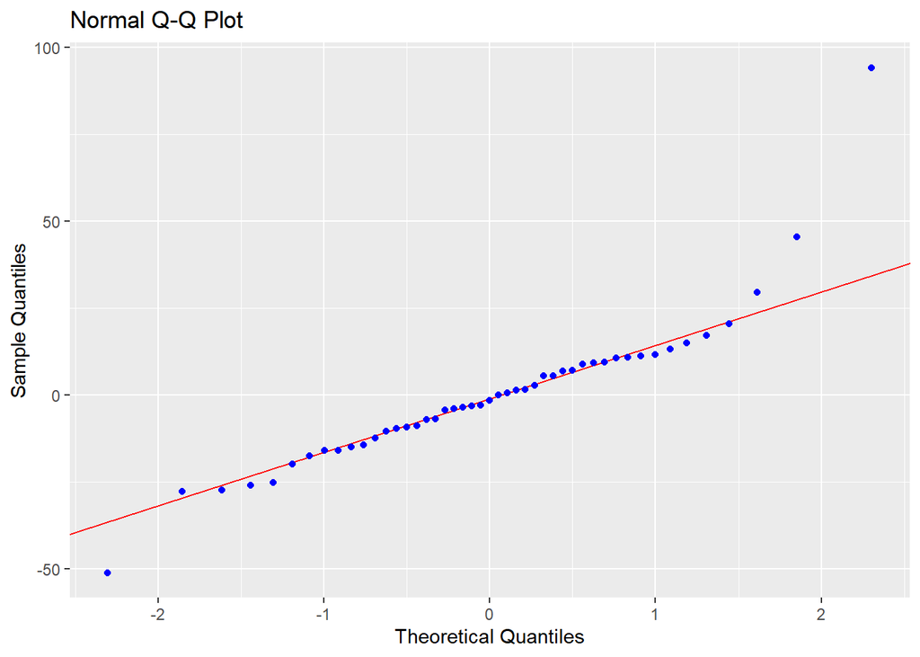

   ```r
   ols_plot_resid_qq(model)
   ```

   ```r
   shapiro.test(resid(model))
   ```

   ```
   ##
   ##  Shapiro-Wilk normality test
   ##
   ## data:  resid(model)
   ## W = 0.86839, p-value = 8.16e-05
   ```

   The $p$-value is $8.16 \times 10^{-5}$. We reject the null hypothesis and conclude that the errors are not normally distributed.
3. (5 points) Check for any high leverage points. Report any observations you determine to have high leverage.

   ```r
   which(hatvalues(model) > 2*mean(hatvalues(model)))
   ```

   ```
   ## 31 33 35 42
   ## 31 33 35 42
   ```

4. (5 points) Check for any outliers in the data set at the $\alpha = 0.05$ significance level. Report any observations you determine to be outliers.

   ```r
   outlier_test_cutoff = function(model, alpha = 0.05) {
       n = length(resid(model))
       qt(alpha/(2 * n), df = df.residual(model) - 1, lower.tail = FALSE)
   }

   # vector of indices for observations deemed outliers.
   cutoff = outlier_test_cutoff(model, alpha = 0.05)

   which(abs(rstudent(model)) > cutoff)
   ```

   ```
   ## 24
   ## 24
   ```

5. (5 points) Check for any highly influential points in the data set. Report any observations your determine are highly influential.

   ```r
   which(cooks.distance(model) > 4 / length(cooks.distance(model)))
   ```

   ```
   ## 24 39
   ## 24 39
   ```

6. (9 points) Fit a model with the high influence points you found in the previous question removed. Perform a hypothesis test at the $\alpha = 0.05$ significance level to check the normality assumption. What do you conclude?

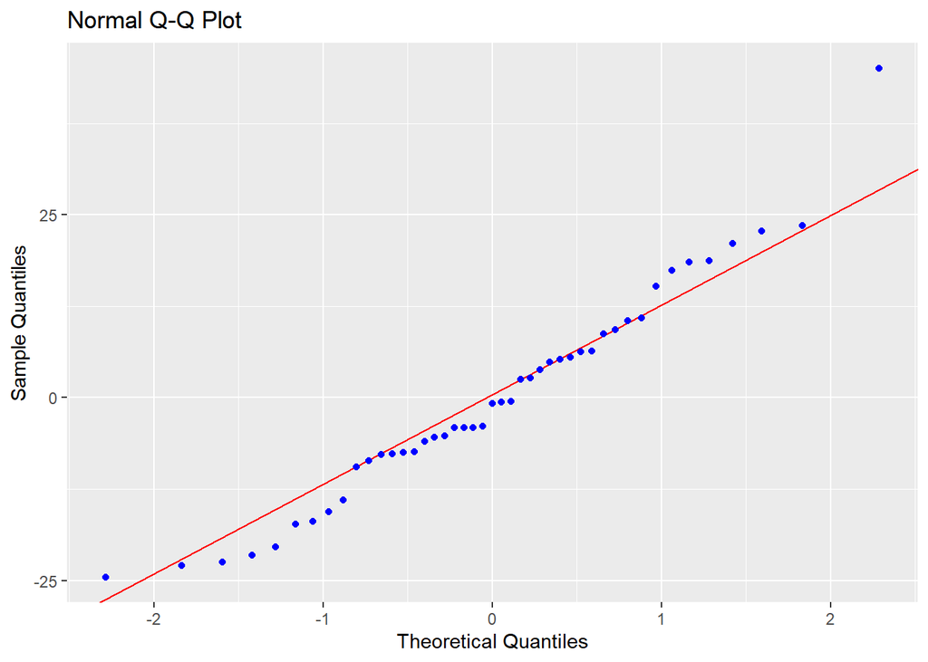

   ```r
   # ids for non-influential observations
   noninfluential_ids = which(
       cooks.distance(model) <= 4 / length(cooks.distance(model)))

   # fit the model on non-influential subset
   fix_model = lm(gamble ~ sex + status + income + verbal,
                  data = teengamb,
                  subset = noninfluential_ids)

   ols_plot_resid_qq(fix_model)
   ```

   ```r
   shapiro.test(resid(fix_model))
   ```

   ```
   ##
   ##  Shapiro-Wilk normality test
   ##
   ## data:  resid(fix_model)
   ## W = 0.96728, p-value = 0.23
   ```

## Exercise 2 (Add Variable Plots for the Teenage Gambling Data) [20 points]

For this exercise, we will also use the `teengamb` data set from the `faraway` package. Some of these questions are subjective, so there may not be a “right” answer. Just make sure to justify your answer based on the plots and statistical tests.

1. (8 points) Fit a multiple linear regression model with `gamble` as the response and the other four variables as predictors. Obtain the partial regression plots. For each predictor, determine if it appears to have a linear relationship with the response after removing the effects of the other predictors based on these plots. Include the plots in your response.

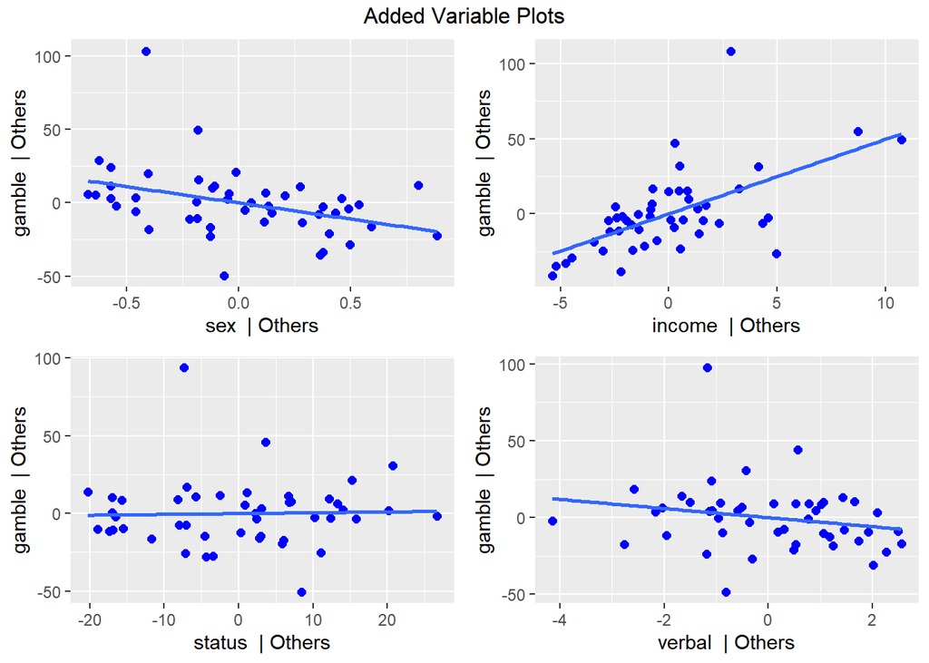

   ```r
   ols_plot_added_variable(model)
   ```

2. (8 points) Fit the following two models and obtain their residuals:
   - Model 1: `gamble` ~ `verbal` + `status` + `sex`.
   - Model 2: `income` ~ `verbal` + `status` + `sex`.

   Next fit a simple linear regression model with the residuals of Model 1 as the response and the residuals of Model 2 as the predictor. Report the value of the slope parameter.

   ```r
   model1 = lm(gamble ~ verbal + status + sex, data = teengamb)
   model2 = lm(income ~ verbal + status + sex, data = teengamb)
   model3 = lm(resid(model1) ~ resid(model2))
   summary(model3)$coeff
   ```

   ```
   ##                    Estimate Std. Error       t value     Pr(>|t|)
   ## (Intercept)   -2.279512e-16  3.1974995 -7.129045e-17 1.000000e+00
   ## resid(model2)  4.961979e+00  0.9906231  5.008948e+00 8.929015e-06
   ```

3. (4 points) Compare the coefficient of `income` from the model fit in part 1 (`gamble` ~ `verabal` + `status` + `sex` + `income`) to the value of the slope parameter in part 2. Are their values the same or different?

   ```r
   summary(model)$coeff
   ```

   ```
   ##                 Estimate Std. Error    t value     Pr(>|t|)
   ## (Intercept)  22.55565063 17.1968034  1.3116188 1.967736e-01
   ## sex         -22.11833009  8.2111145 -2.6937062 1.011184e-02
   ## status        0.05223384  0.2811115  0.1858118 8.534869e-01
   ## income        4.96197922  1.0253923  4.8391032 1.791882e-05
   ## verbal       -2.95949350  2.1721503 -1.3624718 1.803109e-01
   ```

## Exercise 3 (Diagnostics for Swiss Fertility Data) [40 points]

For this exercise we will use the `swiss` data set from the `faraway` package. You can also find the data in `swiss.csv` on Canvas. You can use `?swiss` to learn about the data set. The variables in the data set are

- `Fertility`: a ‘common standardized fertility measure’.
- `Agriculture`: proportion of males involved in agriculture as an occupation.
- `Examination`: proportion of draftees receiving the highest mark on army examination.
- `Education`: proportion with education beyond primary school for draftees.
- `Catholic`: proportion ‘catholic’ (as opposed to ‘protestant’).
- `Infant.Mortality`: proportion of live births who live less than 1 year.

In the following exercise, use `Fertility` as the response and the other variables as predictors. Some of these questions are subjective, so there may not be a “right” answer. Just make sure to justify your answer based on the plots and statistical tests.

1. (8 points) Check the constant variance assumption for this model using a graphical method and a hypothesis test at the $\alpha = 0.05$ significance level. Do you feel it has been violated? Justify your answer. Include any plots in your response.

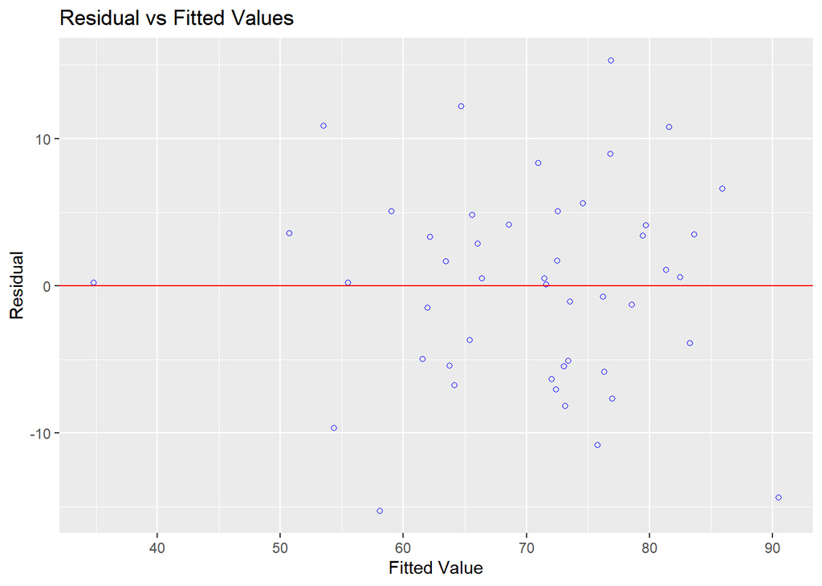

   ```r
   model = lm(Fertility ~ ., data = swiss)
   ols_plot_resid_fit(model)
   ```

   ```r
   bptest(model)
   ```

   ```
   ##
   ##  studentized Breusch-Pagan test
   ##
   ## data:  model
   ## BP = 5.8511, df = 5, p-value = 0.321
   ```

2. (8 points) Check the normality assumption using a Q-Q plot and a hypothesis test at the $\alpha = 0.05$ significance level. Do you feel it has been violated? Justify your answer. Include any plots in your response.

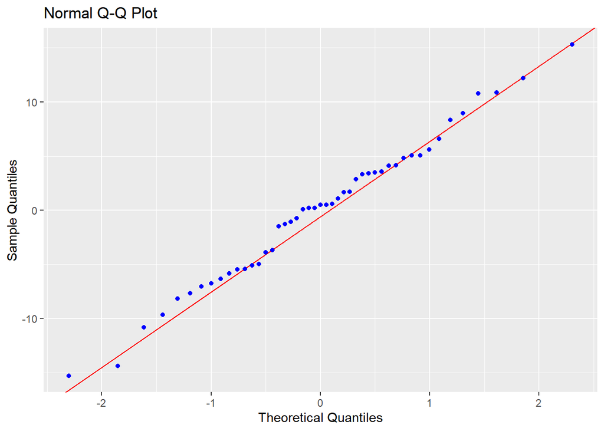

   ```r
   ols_plot_resid_qq(model)
   ```

   ```r
   shapiro.test(resid(model))
   ```

   ```
   ##
   ##  Shapiro-Wilk normality test
   ##
   ## data:  resid(model)
   ## W = 0.98892, p-value = 0.9318
   ```

3. (4 points) Check for any high leverage points. Report any observations you determine to have high leverage.

   ```r
   which(hatvalues(model) > 2*mean(hatvalues(model)))
   ```

   ```
   ##    La Vallee V. De Geneve
   ##           19           45
   ```

4. (4 points) Check for any outliers in the data set at the $\alpha = 0.05$ significance level. Report any observations you determine to be outliers.

   ```r
   outlier_test_cutoff = function(model, alpha = 0.05) {
       n = length(resid(model))
       qt(alpha/(2 * n), df = df.residual(model) - 1, lower.tail = FALSE)
   }

   # vector of indices for observations deemed outliers.
   cutoff = outlier_test_cutoff(model, alpha = 0.05)

   which(abs(rstudent(model)) > cutoff)
   ```

   ```
   ## named integer(0)
   ```

5. (4 points) Check for any highly influential points in the data set. Report any observations your determine are highly influential.

   ```r
   which(cooks.distance(model) > 4 / length(cooks.distance(model)))
   ```

   ```
   ##  Porrentruy      Sierre   Neuchatel Rive Droite Rive Gauche
   ##           6          37          42          46          47
   ```

6. (6 points) Compare the regression coefficients including and excluding the influential observations. Comment on the difference between these two sets of coefficients.

   ```r
   coef(model)
   ```

   ```
   ##      (Intercept)      Agriculture      Examination        Education
   ##       66.9151817       -0.1721140       -0.2580082       -0.8709401
   ##         Catholic Infant.Mortality
   ##        0.1041153        1.0770481
   ```

   ```r
   # ids for non-influential observations
   noninfluential_ids = which(
       cooks.distance(model) <= 4 / length(cooks.distance(model)))

   # fit the model on non-influential subset
   model_fix = lm(Fertility ~ .,
                  data = swiss,
                  subset = noninfluential_ids)

   # return coefficients
   coef(model_fix)
   ```

   ```
   ##      (Intercept)      Agriculture      Examination        Education
   ##      66.44458475      -0.21819812      -0.50016393      -0.69046520
   ##         Catholic Infant.Mortality
   ##       0.09846806       1.35767263
   ```

7. (6 points) Compare the predictions at the highly influential observations based on a model that includes and excludes the influential observations. Comment on the difference between these two sets of predictions.

   ```r
   influential_obs = subset(
       swiss, cooks.distance(model) > 4 / length(cooks.distance(model)))

   # model includes influential observations
   predict(model, influential_obs)
   ```

   ```
   ##  Porrentruy      Sierre   Neuchatel Rive Droite Rive Gauche
   ##    90.50011    76.87869    53.51934    54.36209    58.07426
   ```

   ```r
   # model excludes influential observations
   predict(model_fix, influential_obs)
   ```

   ```
   ##  Porrentruy      Sierre   Neuchatel Rive Droite Rive Gauche
   ##    94.43980    76.33683    55.89622    57.92582    61.32012
   ```